# Final Project: AirBnB New User Bookings

Di Wu, Samuel Chao and Bry Power

## Project Overview

In this project, we will predict in which country a new user will make his/her first booking through AirBnB. There are 12 possible outcomes of the destination country: **‘US’, ‘FR’ (France), ‘CA’ (Canada), ‘GB’ (United Kingdom), ‘ES’ (Spain), ‘IT’ (Italy), ‘PT’ (Portugal), ‘NL’ (Netherlands),‘DE’ (Germany), ‘AU’ (Australia), ‘NDF’ (no destination found), and ‘other’.* Please note that *‘NDF’* is different from *‘other’** because ‘other’ means there was a booking, but is to a country not included in the list, while ‘NDF’ means there wasn’t a booking.

## Data Description

This was originally created as a competition on Kaggle, called [Airbnb New User Bookings](https://www.kaggle.com/c/airbnb-recruiting-new-user-bookings) and the detailed data description were provided [here](https://www.kaggle.com/c/airbnb-recruiting-new-user-bookings/data).

Because the competition ended at the time we started this project and we couldn’t make any submission, I will not use test data. A proportion of the training data set will be hold out and used as our test data to see the performance of our model.

Please note that we blocked the code in the analysis.

## Exploratory Data Analysis

### Target

First let’s take a look at the distribution of users’ destination:

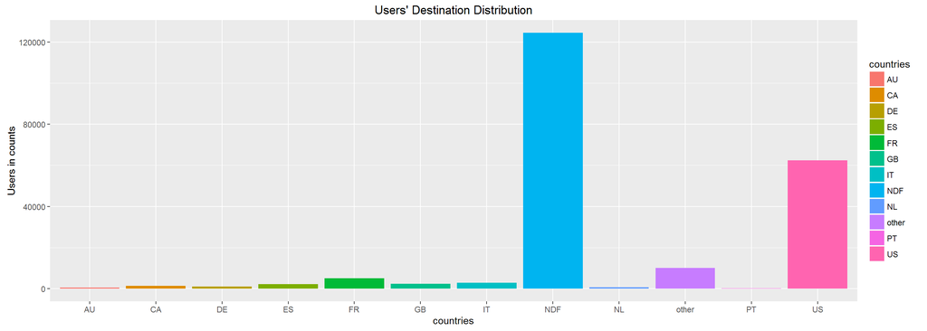

| Countries | Number of Bookings | Percentage of Bookings |
| --- | --- | --- |
| PT - Portugal | 217 | 0.10 |
| AU - Australia | 539 | 0.25 |
| NL - Netherlands | 762 | 0.36 |
| DE - Germany | 1061 | 0.50 |
| CA - Canada | 1428 | 0.67 |
| ES - Spain | 2249 | 1.05 |
| GB - United Kingdom | 2324 | 1.09 |
| IT - Italy | 2835 | 1.33 |
| FR - France | 5023 | 2.35 |
| other | 10094 | 4.73 |
| US - United States | 62376 | 29.22 |
| NDF - no destination found | 124543 | 58.35 |

From users’ booking destinations we can tell most of users didn’t book any trips and among those who booked their first trips, majority of them had chosen *‘US’* as their first destination. This makes sense because all of the users are located in the US and taking financial costs and time in consideration, US natrually should be the most popular destination compared to trips to Europe or even to Australia, which cost users much more money and time.

However, such inbalanced distribution within users’ destinations will generate bias in model. In another word, because there are much more users who chose US than those who chose Europe, model has less opportunties to learn from users whose destination located in Europe.

Oversampling could be a solution for such scenario but oversampled data might NOT be practical as we’ve discussed above, we are to perdict US users’ booking perference not to perdict users’ from all over the world. Therefore, we will leave the target as it is for the rest of our analysis.

### Users’ Demographics Profiling

#### Users’ Gender

Now, let’s take a look at gender distribution against our target. What we are trying to find here is to see if we can combine sub-categories based on its proportion in the data as well as on its penetration against target. That is to compare the difference between each sub-category and within.

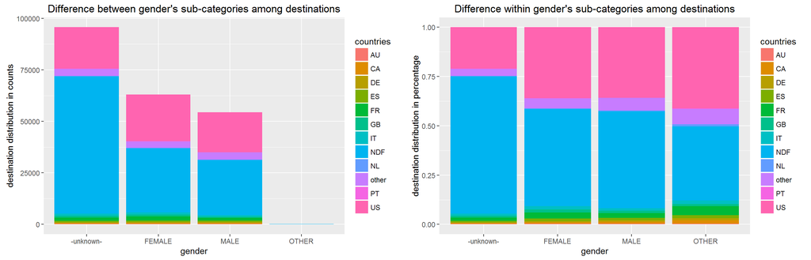

From the bar chart on the left side, we see sub-category “OTHER” is a very small group and therefore we will treat it as “-unknown-”. **From the bar chart on the right side above, we see the booking rate is much higher if we know users’ gender.** We can almost see some slightly difference between male and female’s booking preference as it shows a more colorful spectrum in the bottom from both bars. And from the chart legend, we know more colorful spectrum represents destinations in Europe and Australia. **Therefore, it might indicate that compared to male users, female users preferred to book more romantic destinations.** Now, let’s take a closer look at gender preference among destinations in Europe and Australia.

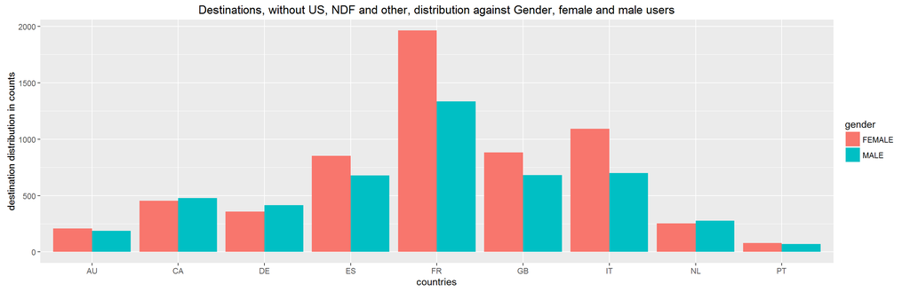

**This chart above confirms our earlier assumption, female users indeed showed a preference to more romantic destinations such as Spain, France, UK and Italy.**

#### Users’ Age

In age variable, we found a lot of missing values and data errors, for example, there are values “2014”, “2008” and ages over 100 or below 10. We think those are data errors and therefore will treat it as missing values. There are also missing ages in the data. Because we will use Extreme Gradient Boosting for modeling, both technique handles well with missing values. We will denote the missing values as -99. Following charts are non-missing ages against users’ destinations.

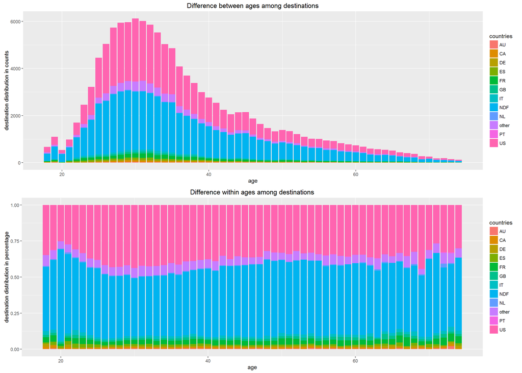

From the first bart chart, we see that majority of non-missing ages is located in between 25 and 40. Compared to other age groups, ages from 25 to 40 has the highest booking rate over all and highest booking rate to US.

This makes sense because users in this group is in the working force which provided the financial ability to travel.

#### Users’ Language

Because all of the users are located in US, over 96% of language is English. We will combine those non-English languages into one new category based on this in order to produce a robust model performance. However, we would assume that users with French background maybe more likely to travel to France but these non-English languages are too small, we would only use language as an indicator variable with two levels: English or non-English.

In order to visualize these data, we used log transformation in the following chart.

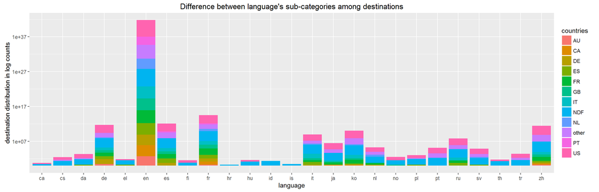

### Users’ Signup Information

#### Users’ Signup Method

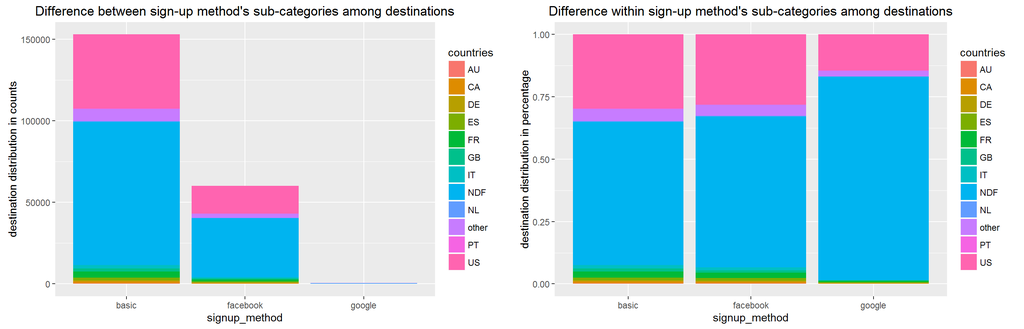

We can tell users whose signup method is “basic” has a higher booking rate from the bar chart above. Although sub-category “google” is very small, about 550 users, we will not combine this to any of the other two categories because from the chart on the right side, the destination distribution within this group looks very different than the other two.

#### Users’ Signup Flow

This variable shows the page a user came to signed up from. It creates a lot of noise in the data as there is ONE dominating sub-category, page-0, taking about 78% of the data and a few other smaller pages, for example page-2, page-3, page-12. The remaining sub-categories almost are very small and only took about 1% of the data. We will combine these small groups. To better visualize the data, we again used log transformation.

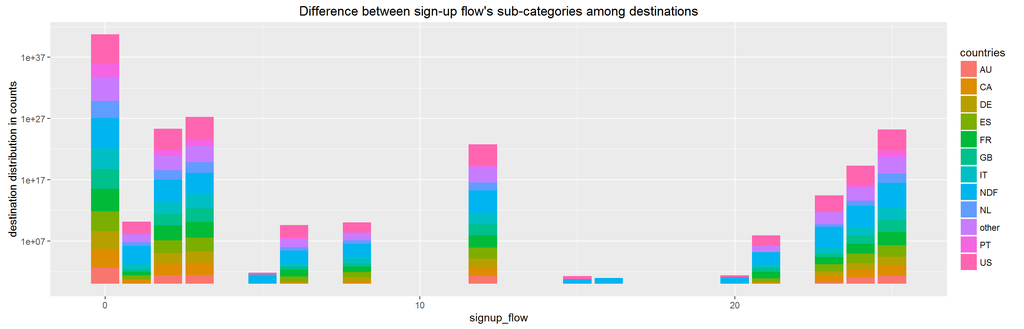

#### Users’ Signup App

This variable shows the application a user signed up from. There are four sub-categories, Android, iOS, Moweb and Web, where Android and iOS are mobile apps, Web is a desktop app and moweb could be a combination of both.

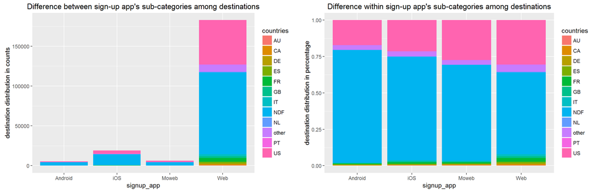

Mayjority of the users signed up from a desktop and they generated a higher booking rate. Beside that, we also see that compared to Android, there are more users signed up using iOS and they did also generated a higher booking rate. **It tells us that AirBnB should place more focus on users who signed up using iPhone compared to Android phones.**

We will confirm this story in next categorical varible, first signed up device.

#### Users’ First Signup Device

In this variable, there are about 9 sub-categories but in fact partition it into 5, which are Apple Mobile, “iPad” and “iPhone”; Apple desktop, “Mac Desktop”; Android, “Android Phone” and “Android Tablet”; Windows, “Windows Desktop” and other, “Desktop(other)”, “other/unknown”, “smartphone”.

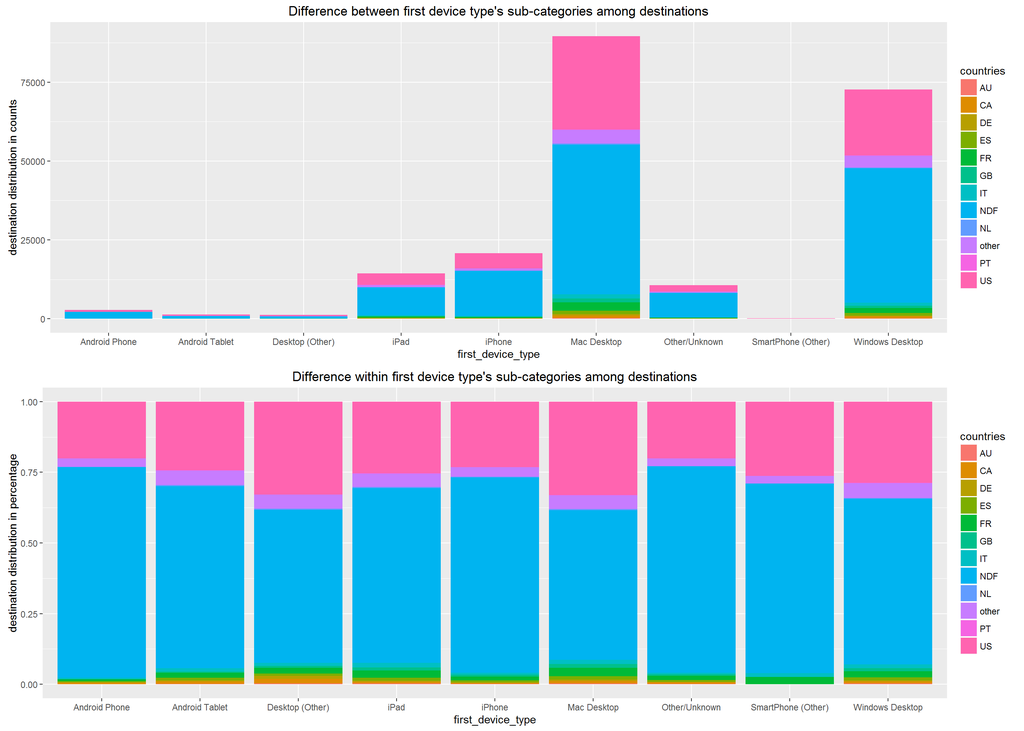

This is again confirmed our earlier story. Majority of the users are Apple users and desktop users generates a higher booking rate. A closer look at within mobile device, iOS users is agian the majority and generally outperforms Android users. Among users who signed from a computer rather than a phone, those who used Mac seems a more colorful spectrum in the bottom of the bar compared to those used Windows desktop.

**From these two variables, we are probably more confident to say that AirBnB should place more focus on the Apple users.**

#### Users’ Web Browsers

This variable contains the history of users’ web browser when users landed on AirBnB’s page for the first time. It is similiar to signup page flow, also contains a few dominating subcategories such as “-unknown-, 12.77%”, “Chrome, 29.91%”, “Firefox, 15.77%”, “IE, 9.87%”, “Mobile Safri, 9.03%”, “Safari, 21.16%”, and the rest took about 1% of the data. We will therefore bin the rest of subcategories into one. We visualized the browser distribution against destinations in log.

[figure not shown]

### Marketing Information

#### Affiliate Channels

This variable contains the marketing channels that AirBnB used to connect to the users. There are 8 subcategories within and we will create dummy variables to represent this variable. We again visualized it in log transformation.

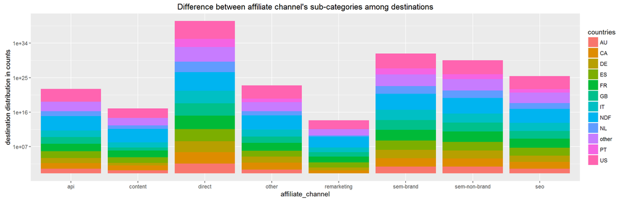

#### Affiliate Provider

This variable indicates where the marketing material was displayed. Two dominating subcategories: “direct, 64.38%” and “google, 24.33%”. The rest of it took about 10% of the data, which was grouped into one. We again visualized it in log transformation.

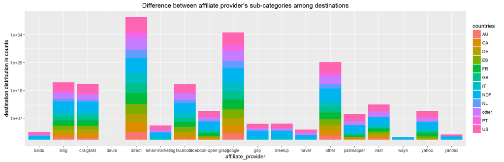

#### First Affiliate tracked

This variable contains information about what marketing material a user first interacted with before the signing up. Unfortunately, the website didn’t provide detailed information about this and we’ve searched online, nothing useful popped up.

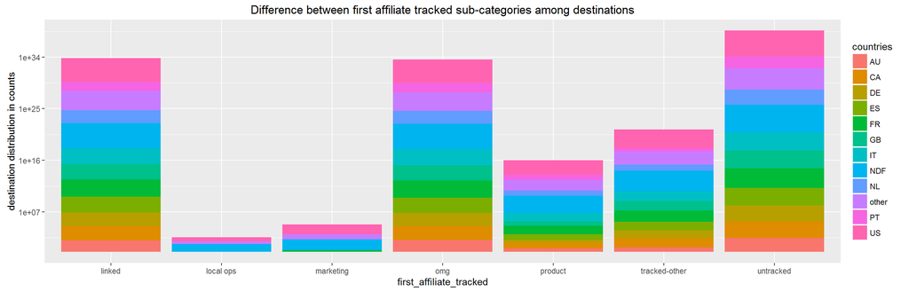

The three marketing variables above provided information about users’ preference on the marketing channels and marketing material. They can be very useful. The strategy for us is that to generate stable indicators and have them interacted with each other in the modelling stage.

### Date variables

#### First booking since user’s first active action

This variable is derived from two provided data variables, first active time stamp and date user first booking. Because not all the used had booking history(“NDF - no destination found”s), there are about 58% of them are missing. Again, we wouldn’t worry about this because the nature of the algorithm we are using.

[figure not shown]

#### First booking since user created file on AirBnB

This variable is derived from two provided data variables, date user created account and date user first booking. Because not all the used had booking history(“NDF - no destination found”s), there are about 58% of them are missing. Again, we wouldn’t worry about this because the nature of the algorithm we are using.

[figure not shown]

These two variables behaved quitely similiarly and that might be caused by the varialbe, date user created account, and variable, user first active action, are similiar in the sense of they might be created around the same time. We investigated it and it is in fact the reason. Over 99.9% of users’ first activity on AirBnB is recorded at the same day as the date of account creation.

We will then just use the first booking since user created file on AirBnB variable.

### Web Session Log

This is provided in a separated data set and it contains the users’ action, actiion type and action details. One user might contains hundreds of web browsing actiion records. We also found that among 135,483 unique users in this data set, only 73,815 users are contained in the training data set. This means only 35% of users in training has some information from web session log. It brought the issues of robustness again because we know, in practics, variables with 80% of missing value will not provide valuable information to the model and will NOT however produce a stable prediction.

We aggregated the values to user level and counted the number of times each actions, action types and action details occured. However, most of these informations contains over 80% of missing values in training data set and therefore, we decided to use it as indicators. Continuous values won’t provide stable results.

We also noticed that these three variables are very noisy and lays on each other. For example, there hundreds of different actions, and some actions are associated with empty valued action types and detail. To exclude the noise from modeling development stage, we chose only action types because it is the least sparse and more representitive for users’ web browsing behaviors.

We regrouped the sub-categories by its size and meaning. For example, “message to host change”, “contact_host” would be regrouped into “contact host”.

As for now, we have cleaned the data relied on the information gained from data explorary analysis and also derived more analytical varaibles for modeling. Please note it that some of the data manipulation was done in SAS. The SAS code is provided in our [repository](https://github.com/ErnstWu/DS-FinalProject) on GitHub.

## Model Development

From here, we will use cleaned data and derived variables for modeling. The modeling data set can be found in our [repository](https://github.com/ErnstWu/DS-FinalProject) on GitHub.

### Partition the dataset

We will create two dataset randomly splitted from the original training dataset in proportion of 4:6 because as we mentioned earlier, the competition is over; we couldn’t make any submissions. We will use 40% of the data from the original training dataset as our hold-out test set and 60% of them as our new training dataset. Because this dataset is still very big, we will sample 30% of them to model.

### Extreme Gradient Boosting

#### Cross Validation

Here we used cross validation to adjust the parameters.

What we are looking for here is an increase in test errors, if we see one, then we know where to stop. We could try a few different set of parameters but this is the one we found after a few try. Next we build the function.

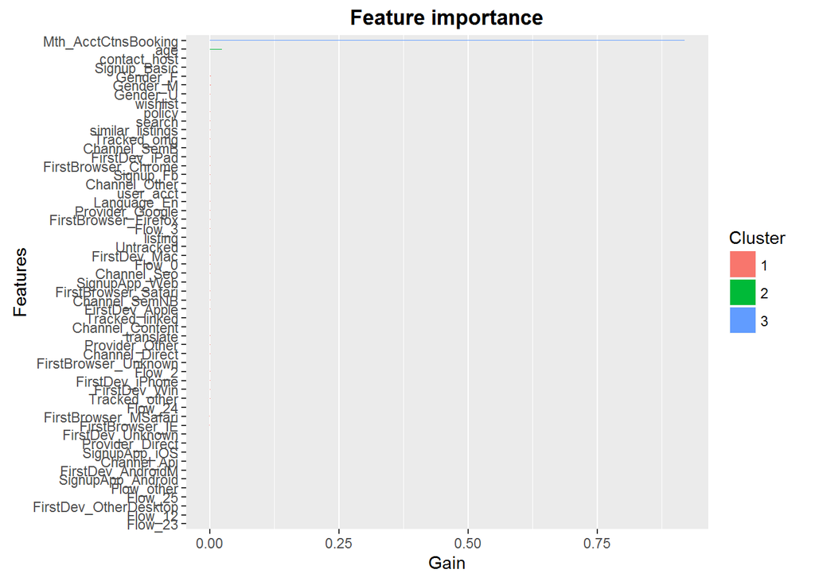

#### Re-apply the modeling the process without confounding variable.

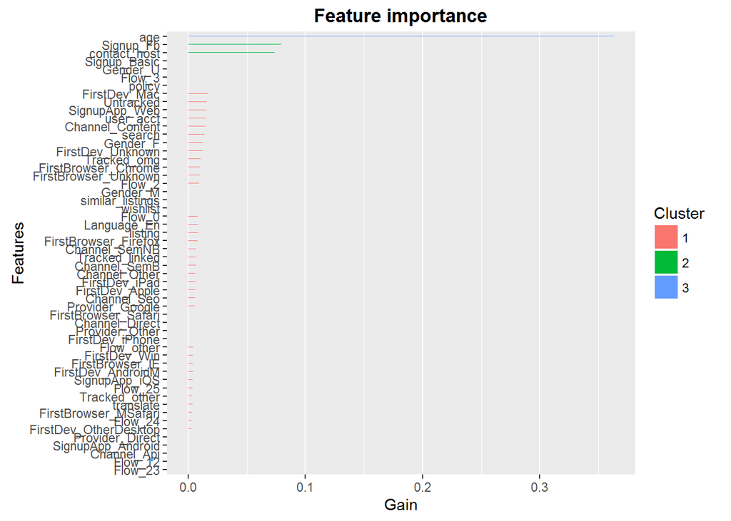

Now let’s check how did the xgboost model do on test data.

| method | ErrorRate |
| --- | --- |
| XGBoost | 0.3808035 |